# Homework 10

Chueh-Ju Kuo

2026-02-11

## Instructions

Answer the following questions and complete the exercises in RMarkdown. Please embed all of your code and push your final work to your repository. Your final lab report should be organized, clean, and run free from errors. Remember, you must remove the `#` for the included code chunks to run. Be sure to add your name to the author header above.

Make sure to use the formatting conventions of RMarkdown to make your report neat and clean!

## Background

In the `data` folder, you will find data about shark incidents in California between 1950-2022. The [data](https://catalog.data.gov/dataset/shark-incident-database-california-56167) are from: State of California- Shark Incident Database.

## Load the libraries

```r
library("tidyverse")
library("janitor")
```

## Load the data

Run the following code chunk to import the data. In this chunk, I am removing NA’s.

```r
sharks <-
  read_csv("data/SharkIncidents_1950_2022_220302.csv",
           na=c("NA", "N/A", "Unknown", "NOT COUNTED", "", " ")) %>%
  clean_names()
```

```r
glimpse(sharks)
```

```
## Rows: 211
## Columns: 16
## $ incident_num     <dbl> 1, 2, 3, 4, 5, 6, 7, 8, 9, 10, 11, 12, 13, 14, 15, 16…
## $ month            <dbl> 10, 5, 12, 2, 8, 4, 10, 5, 6, 7, 10, 11, 4, 5, 5, 8, …
## $ day              <dbl> 8, 27, 7, 6, 14, 28, 12, 7, 14, 28, 4, 10, 24, 19, 21…
## $ year             <dbl> 1950, 1952, 1952, 1955, 1956, 1957, 1958, 1959, 1959,…
## $ time             <chr> "12:00", "14:00", "14:00", "12:00", "16:30", "13:30",…
## $ county           <chr> "San Diego", "San Diego", "Monterey", "Monterey", "Sa…
## $ location         <chr> "Imperial Beach", "Imperial Beach", "Lovers Point", "…
## $ mode             <chr> "Swimming", "Swimming", "Swimming", "Freediving", "Sw…
## $ injury           <chr> "major", "minor", "fatal", "minor", "major", "fatal",…
## $ depth            <chr> "surface", "surface", "surface", "surface", "surface"…
## $ species          <chr> "White", "White", "White", "White", "White", "White",…
## $ comment          <chr> "Body Surfing, bit multiple times on leg, thigh and b…
## $ longitude        <chr> "-117.1466667", "-117.2466667", "-122.05", "-122.15",…
## $ latitude         <dbl> 32.58833, 32.58833, 36.62667, 36.62667, 35.13833, 35.…
## $ confirmed_source <chr> "Miller/Collier, Coronado Paper, Oceanside Paper", "G…
## $ wfl_case_number  <chr> NA, NA, NA, NA, NA, NA, NA, NA, NA, NA, NA, NA, NA, N…
```

## Questions

1. Are there any “hotspots” for shark incidents in California? Show the top five counties with the most incidents.

```r
sharks%>%
  select(county, incident_num)%>%
  group_by(county)%>%
  count(incident_num) %>%
  summarize(total_incident=sum(n))%>%
  arrange(desc(total_incident))%>%
  slice_max(total_incident, n=5)
```

```
## # A tibble: 6 × 2
##   county        total_incident
##   <chr>                  <int>
## 1 San Diego                 25
## 2 Humboldt                  20
## 3 San Mateo                 19
## 4 Santa Barbara             19
## 5 Marin                     16
## 6 Monterey                  16
```

2. Make a plot that shows the total number of incidents per county.

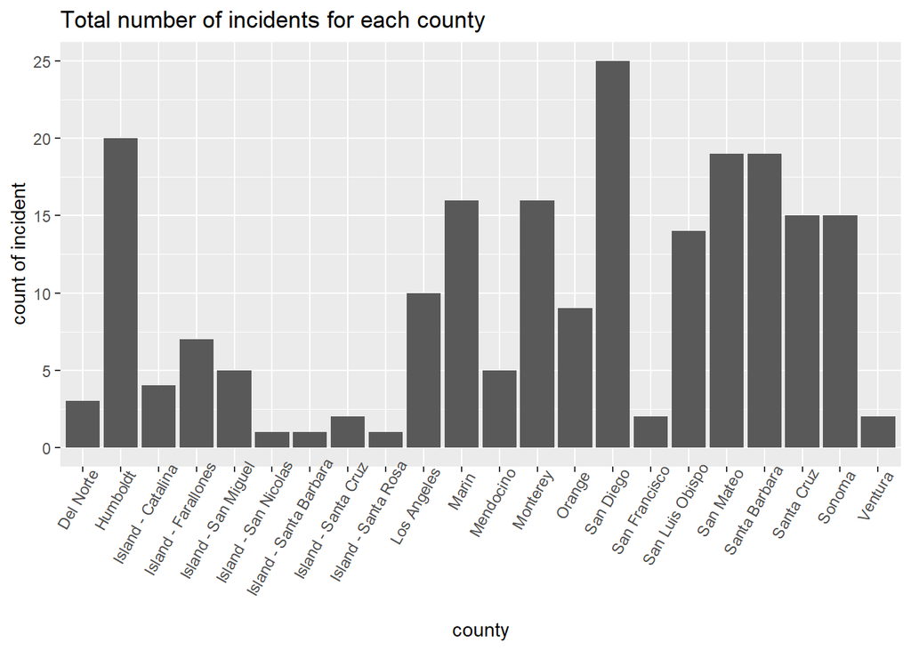

```r
sharks%>%
 select(county, incident_num)%>%
  group_by(county)%>%
  count(incident_num) %>%
  summarize(total_incident=sum(n))%>%
  ggplot(aes(x=county, y=total_incident))+geom_col()+theme(axis.text.x=element_text(angle=60, hjust=0.85))+labs(title="Total number of incidents for each county", x="county", y="count of incident")
```

3. Are there months of the year when incidents are more likely to occur? Make a plot that shows the total number of incidents by month. Which month has the highest number of incidents? October

```r
sharks%>%
  select(month, incident_num)%>%
  group_by(month)%>%
  count(incident_num)%>%
  summarize(total_incident_month=sum(n, na.rm=T))%>%
  arrange(desc(total_incident_month))
```

```
## # A tibble: 12 × 2
##    month total_incident_month
##    <dbl>                <int>
##  1    10                   36
##  2     9                   34
##  3     8                   31
##  4     7                   27
##  5     5                   16
##  6    11                   16
##  7     6                   14
##  8    12                   13
##  9     1                    8
## 10     4                    7
## 11     3                    5
## 12     2                    4
```

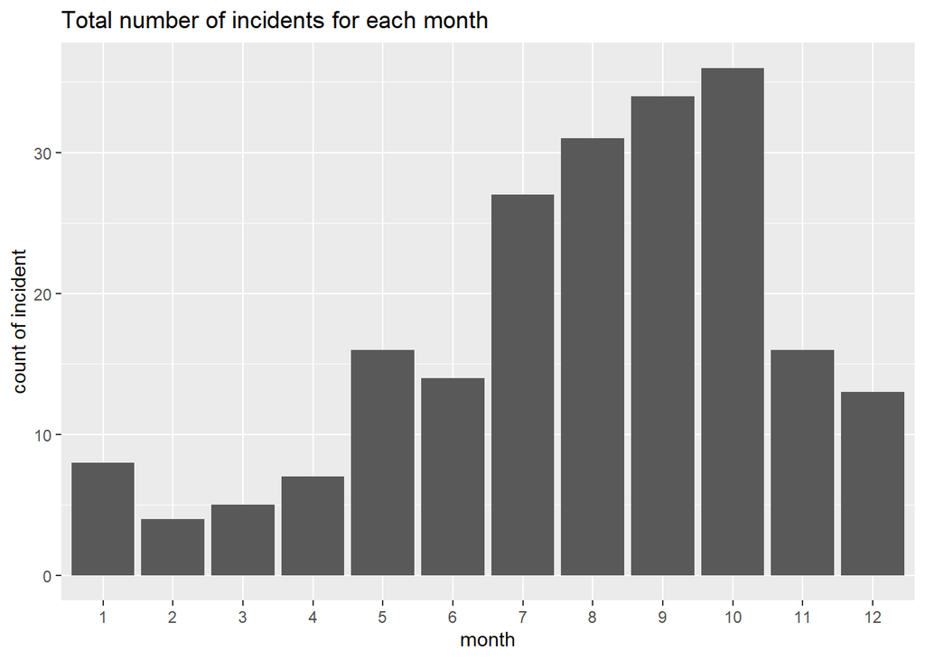

```r
sharks%>%
  select(month, incident_num)%>%
  group_by(month)%>%
  count(incident_num)%>%
  ggplot(aes(x=as.factor(month), y=n))+geom_col()+labs(title="Total number of incidents for each month", x="month", y="count of incident")
```

4. Is there a time of day when most attacks occur? Make a plot that shows the total number of incidents by time of day. Which time of day has the highest number of incidents?

```r
sharks%>%
  select(time,incident_num)%>%
  group_by(time)%>%
  count(incident_num)%>%
  summarize(total_incident_hour=sum(n, na.rm=T))%>%
  arrange(desc(total_incident_hour))
```

```
## # A tibble: 54 × 2
##    time  total_incident_hour
##    <chr>               <int>
##  1 <NA>                   24
##  2 11:00                  18
##  3 9:00                   12
##  4 14:00                  10
##  5 17:30                  10
##  6 12:00                   9
##  7 13:30                   9
##  8 7:30                    8
##  9 17:00                   7
## 10 14:30                   6
## # ℹ 44 more rows
```

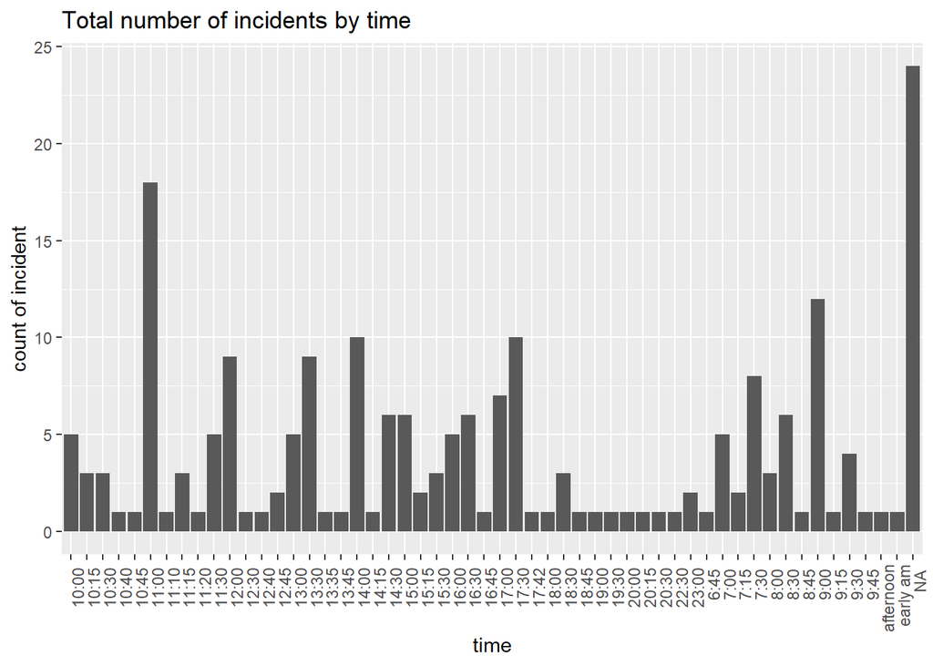

```r
sharks%>%
   select(time,incident_num)%>%
  group_by(time)%>%
  count(incident_num)%>%
  summarize(total_incident_hour=sum(n, na.rm=T))%>%
  ggplot(aes(x=as.factor(time), y=total_incident_hour))+geom_col()+labs(title="Total number of incidents by time", x="time", y="count of incident")+theme(axis.text.x=element_text(angle=90, hjust=0.85))
```

5. How do the number and types of injuries compare by county? Make a table that shows the number of injury types by county. Which county has the highest number incidents? (hint: your table should be in wide format) San Diego

```r
sharks_injury<- sharks%>%
  group_by(county, injury)%>%
  mutate(injury=str_remove(injury, "\\*"))%>%
  summarise(total_incident_county = n())%>%
  pivot_wider(names_from = "injury",
              values_from ="total_incident_county")%>%
  mutate(total_incident_county=rowSums(across(where(is.numeric)), na.rm=T))%>%
  arrange(desc(total_incident_county))
```

[output not shown]

6. Use the table from #5 to make a plot that shows the total number of incidents by county.

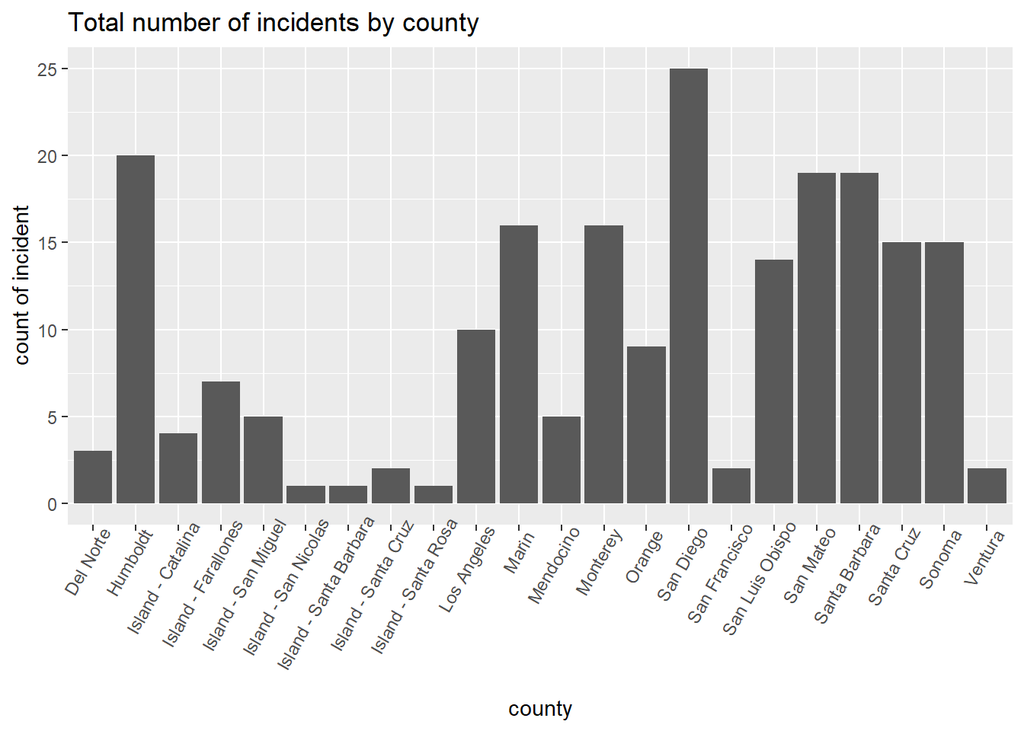

```r
sharks_injury%>%
  ggplot(aes(x=county, y=total_incident_county))+geom_col()+labs(title="Total number of incidents by county", x="county", y="count of incident")+theme(axis.text.x=element_text(angle=60, hjust=0.85))
```

7. In the data, `mode` refers to a type of activity. Which activity is associated with the highest number of incidents? Surfing / Boarding

```r
sharks%>%
  select(mode, incident_num)%>%
  group_by(mode)%>%
  count(incident_num, name="total_incident_mode")%>%
  summarize(total_incident_mode=sum(total_incident_mode, na.rm=T))%>%
  arrange(desc(total_incident_mode))
```

```
## # A tibble: 8 × 2
##   mode                total_incident_mode
##   <chr>                             <int>
## 1 Surfing / Boarding                   85
## 2 Freediving                           36
## 3 Kayaking / Canoeing                  30
## 4 Swimming                             22
## 5 Scuba Diving                         20
## 6 Hookah Diving                        10
## 7 Paddleboarding                        7
## 8 Walking in shallow                    1
```

8. Make a plot that compares the number of incidents by activity.

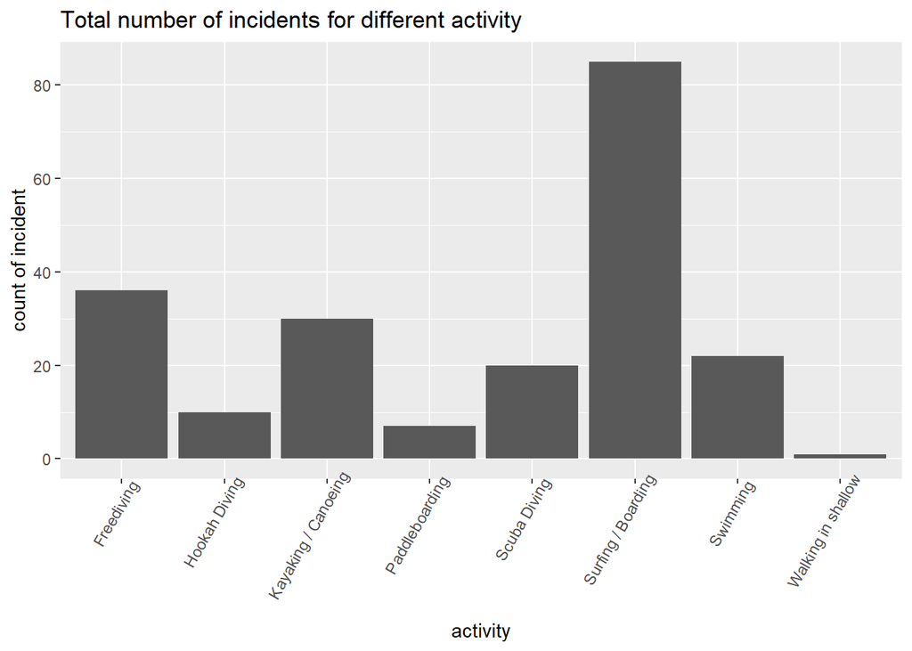

```r
sharks%>%
  select(mode, incident_num)%>%
  group_by(mode)%>%
  count(incident_num, name="total_incident_mode")%>%
  ggplot(aes(x=mode, y=total_incident_mode))+geom_col(na.rm=TRUE)+labs(title="Total number of incidents for different activity", x="activity", y="count of incident")+theme(axis.text.x=element_text(angle=60, hjust=0.85))
```

9. Which shark species is involved in the highest number of incidents?  
   White

```r
sharks%>%
  select(species, incident_num)%>%
  group_by(species)%>%
  count(incident_num, name="total_incident_month")%>%
  summarize(total_incident_month=sum(total_incident_month, na.rm=T))%>%
  arrange(desc(total_incident_month))
```

```
## # A tibble: 12 × 2
##    species      total_incident_month
##    <chr>                       <int>
##  1 White                         181
##  2 <NA>                           14
##  3 Hammerhead                      3
##  4 Blue                            2
##  5 Killer Whale                    2
##  6 Leopard                         2
##  7 Salmon                          2
##  8 Blue*                           1
##  9 Mako                            1
## 10 Sevengill                       1
## 11 Thresher                        1
## 12 blue                            1
```

10. Are all incidents involving Great White’s fatal? Make a plot that shows the number and types of incidents for Great White’s only.

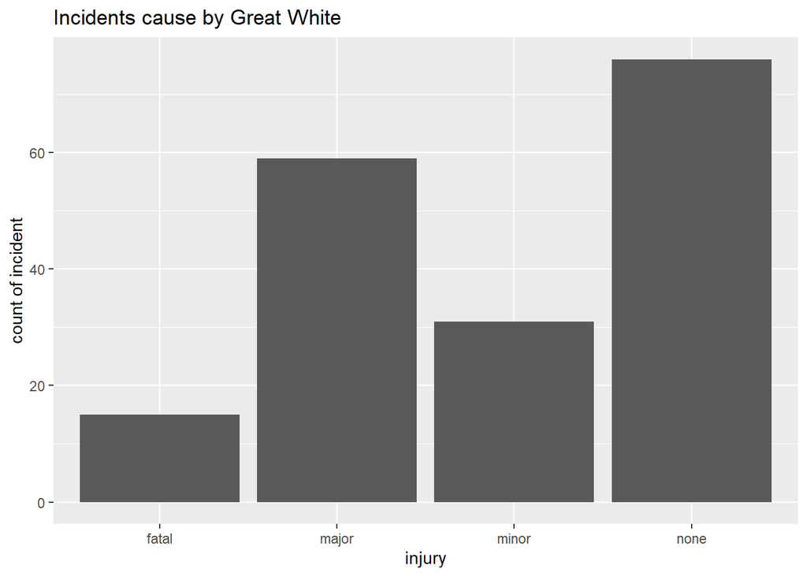

```r
sharks%>%
  select(species, incident_num,injury)%>%
  filter(species=="White")%>%
  mutate(injury=str_remove(injury, "\\*"))%>%
  group_by(injury)%>%
  count(incident_num, name="total_incident_injury_white")%>%
  ggplot(aes(x=injury, y=total_incident_injury_white, na.rm=T))+geom_col()+labs(title="Incidents cause by Great White", x="injury", y="count of incident")
```

## Knit and Upload

Please knit your work as an .html file and upload to Canvas. Homework is due before the start of the next lab. No late work is accepted. Make sure to use the formatting conventions of RMarkdown to make your report neat and clean!